# Spit depths and depths and spits of samples collected for radiocarbon dating at Gua Mo’o hono, Sulawesi

### Spit depths

Convert the field measurements to be relative to the datum, then convert to to be relative to the ground surface (ie. the start depths of spit one).

```r
# relate every spit depth back to the datum
spit_depths[] <- sapply(spit_depths, as.numeric)
relative_to_datum <- spit_depths$datum - spit_depths[,4:13]
# take average of start levels of spit one for
# ground surface relative to datum
ground_surface <- mean(as.numeric(relative_to_datum[1,1:4]))
# now compute relative to ground surface, this should give
# values that we can read as actual depths below the surface
relative_to_ground_surface <- relative_to_datum + abs(ground_surface)
relative_to_ground_surface$spit <- spit_depths$Spit
relative_to_ground_surface
```

```
##    NW..start NE..start SE..start SW..start NW..end NE..end SE..end SW..end
## 1      0.010    -0.020     0.005     0.005  -0.090  -0.125  -0.105  -0.085
## 2     -0.090    -0.125    -0.105    -0.090  -0.185  -0.215  -0.195  -0.200
## 3     -0.185    -0.215    -0.195    -0.195  -0.290  -0.280  -0.290  -0.280
## 4     -0.288    -0.298    -0.297    -0.280  -0.390  -0.443  -0.395  -0.410
## 5     -0.390    -0.443    -0.395    -0.410  -0.485  -0.510  -0.495  -0.505
## 6     -0.485    -0.510    -0.495    -0.505  -0.595  -0.603  -0.590  -0.615
## 7     -0.595    -0.603    -0.590    -0.615  -0.679  -0.685  -0.665  -0.665
## 8     -0.678    -0.690    -0.690    -0.670  -0.779  -0.795  -0.790  -0.795
## 9     -0.779    -0.795    -0.790    -0.795  -0.888  -0.895  -0.875  -0.893
## 10    -0.888    -0.895    -0.875    -0.893      NA      NA      NA      NA
## 11        NA        NA        NA        NA  -0.980  -1.015  -0.985  -1.000
## 12    -0.980    -1.015    -0.985    -1.000  -1.090  -1.105  -1.095  -1.080
## 13    -1.090    -1.105    -1.095    -1.080  -1.200  -1.220  -1.195  -1.200
## 14    -1.200    -1.220    -1.200    -1.195  -1.315  -1.330  -1.295  -1.315
```

[output cut: 55 more lines]

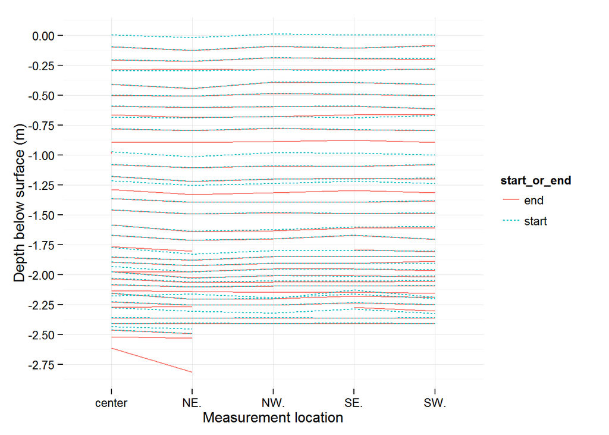

```r
# plot
spits_m <- melt(relative_to_ground_surface, id.var = 'spit')
spits_m$start_or_end <- ifelse(grepl("end", spits_m$variable), "end", "start")
remove <- c(".end", ".start")
spits_m$spit_start_or_end <- with(spits_m, paste0(spit, "_", start_or_end))
spits_m$variable <- gsub(paste(remove, collapse = "|"), "", spits_m$variable)
ggplot(spits_m, aes(variable, value, group = spit_start_or_end, linetype =  start_or_end, colour = start_or_end)) +
  geom_line() +
  theme_minimal() +
  scale_y_continuous(breaks = seq(-3,0,0.25)) +
  xlab("Measurement location") +
  ylab("Depth below surface (m)")
```

```r
# how deep was spit nine?
nine_start <- round(mean(filter(spits_m, spit == 9, start_or_end == "start")$value),2)
nine_end <- round(mean(filter(spits_m, spit == 9, start_or_end == "end")$value),2)
```

The lowest pottery is in spit nine, which is between 0.79 and 0.89 meters below the surface.

### Assignment of dated samples to specific spits

The dated samples were taken from the south wall and their depths can be measured from the section drawing. With these depths we can find the spit depths from the SW and SE corners that will identify the spit that correlates with the dated sample.

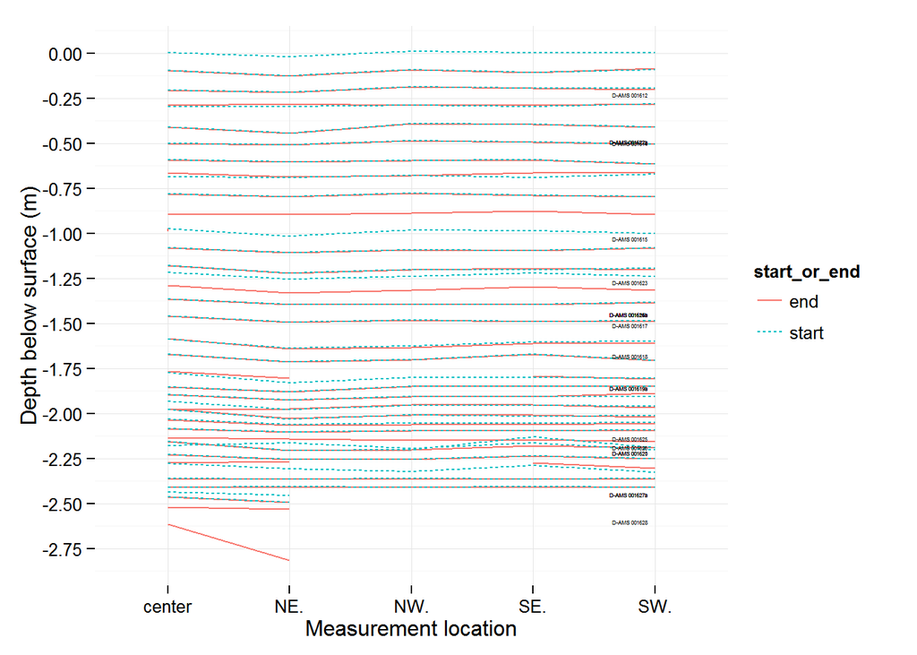

```r
dates_calib$section <- "SW."
# plot spits with dated samples
ggplot(spits_m, aes(variable, value)) +
  geom_line(aes(group = spit_start_or_end, linetype =  start_or_end, colour = start_or_end)) +
 geom_text(data = dates_calib, aes(section, -Depth.below.surface..m., label = DirectAMS.code), size = 1, hjust = 1.2) +
  theme_minimal() +
  scale_y_continuous(breaks = seq(-3,0,0.25)) +
  xlab("Measurement location") +
  ylab("Depth below surface (m)")
```

Here we can see which spits the dated sample fall into.

```r
# match sample depths up with a specific spit from SW-SE data
relative_to_ground_surface$South_means <- with(relative_to_ground_surface, apply(cbind(SE..end, SW..end), 1, mean))
South_depth_means <- sort(as.vector(na.omit(apply(cbind(relative_to_ground_surface$SE..end, relative_to_ground_surface$SW..end), 1, mean))), decreasing = FALSE)
intervals <- cbind(-dates_calib$Depth.below.surface..m., findInterval(-dates_calib$Depth.below.surface..m., South_depth_means))
means <- merge(data.frame(South_depth_means), relative_to_ground_surface, by.x = 'South_depth_means', by.y = 'South_means')
means <- arrange(means, South_depth_means)
# subset the table of spit depths with the intervals that the samples come from,
# and these are the spits that correlate with the depths that the dated samples
# were taken from in the South wall
df <- (list(means[intervals[,2], ]$spit,
           dates_calib$Depth.below.surface..m.,
           dates_calib$Name,
           dates_calib$material,
           dates_calib$BP,
           dates_calib$to,
           dates_calib$from))
df <- data.frame(sapply(df,'[',seq(max(sapply(df,length)))))
names(df) <- c("spit", "depth below surface", "code", "material", "uncal age","to cal BP", "from cal BP")
df
```

```
##    spit depth below surface                 code material uncal age
## 1     3                0.23  R_Date D-AMS 001612    Shell      1103
## 2     5                 0.5  R_Date D-AMS 001614    Shell      1690
## 3    11                1.03  R_Date D-AMS 001615    Shell      4202
## 4    15                1.45 R_Date D-AMS 001616a    Shell      4730
## 5    15                1.45 R_Date D-AMS 001616b Organics      3905
## 6    16                1.51  R_Date D-AMS 001617    Shell      4702
## 7    17                1.68  R_Date D-AMS 001618    Shell      6808
## 8    20                1.86 R_Date D-AMS 001619a    Shell      6531
## 9    20                1.86 R_Date D-AMS 001619b Organics      5371
## 10   27                2.22  R_Date D-AMS 001620    Shell      6855
## 11   27                2.22  R_Date D-AMS 001621 Organics      5460
## 12    5                0.49 R_Date D-AMS 001622a    Shell      1568
## 13    5                0.49 R_Date D-AMS 001622b Organics       450
## 14   13                1.27  R_Date D-AMS 001623 Organics      3452
```

[output cut: 29 more lines]

The implication for bone point phases is that it puts the start of phase C squarely in spit 17. Otherwise it’s consistent with David’s calculations.